# Stat4DS / Homework 03

Giuseppe Calabrese, Michele Cernigliaro

31/01/2019

## Exercise part-B: Deep-Sky-Bayes

*Consider a lognormal model with location and scale parameters $\mu$ and $\sigma$ for the stellar mass.*

#### 0. Explore the dataset with some standard plot (e.g. histogram, density plot, boxplot, etc) and summary statistics (location, variability, skewness and kurtosis). Briefly comment on the shape of the mass distribution.

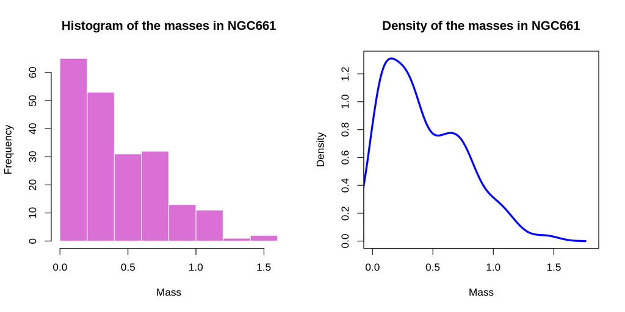

```r
df <- read.csv("NGC6611.csv")

# histogram and density ---------------------------------------------------

par(mfrow = c(1,2))
hist(df$Mass, col = 'orchid', border = 'white',
     main = "Histogram of the masses in NGC661", xlab = "Mass")

d <- density(df$Mass)
plot(d, col = "blue", lwd = 3, xlim = c(0, 1.8),
     main = "Density of the masses in NGC661", xlab = "Mass")
```

```r
par(mfrow = c(1,1))
```

The histogram of the masses recorded in the NGC6611 dataset shows that the most common mass values are under 0.5. Moreover, as the value of the mass increases, we get a lower number of observations.

The density plot shows a multimodal distribution even though the distribution is quite decreasing after the first mode.

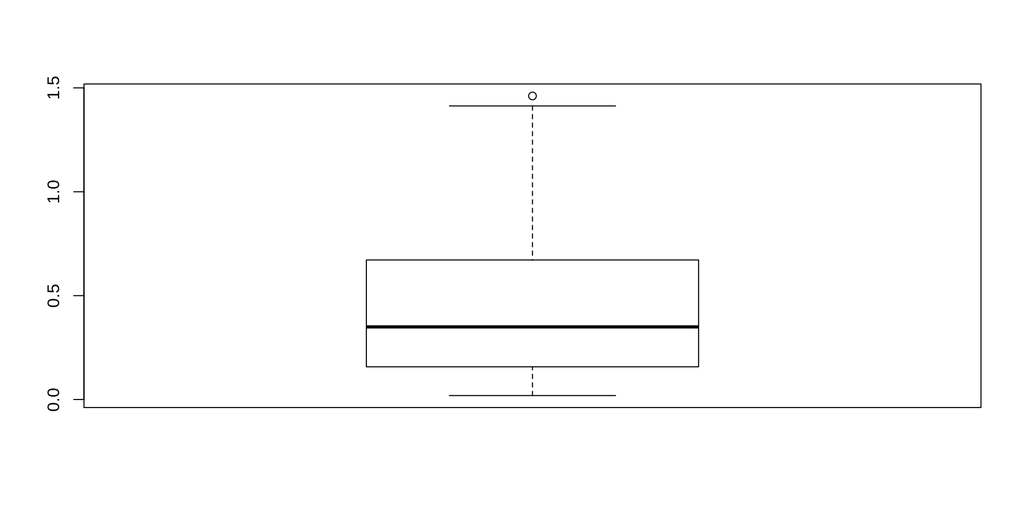

```r
# boxplot -----------------------------------------------------------------

b <- boxplot(df$Mass)
```

```r
stats <-c(b$stats)
names(stats) <- c("lower whisker", "lower hinge", "median", "upper hinge", "upper whisker")

c(stats, IQR = IQR(df$Mass), outlier = b$out)
```

```
## lower whisker   lower hinge        median   upper hinge upper whisker
##        0.0190        0.1575        0.3495        0.6715        1.4130
##           IQR       outlier
##        0.5135        1.4610
```

As we can see, the data is right-skewed. There’s only one outlier which is above the upper whisker. The middle 50% of the data is spread over a range of 0.5135, from 0.1575 to 0.6715.

*summary statistics*

```r
# skewness and kurtosis functions -----------------------------------------

# sample skewness
skewn <- function (X) {
  n <- length(X)
  num <- 1 / n * sum((X-mean(X))^3)
  den <- 1 / (n-1) * sum((X-mean(X))^2)

  num/(den^(3/2))
}
# skewness is a measure of asymmetry around the mean.

# sample kurtosis
kurt <- function(x) {
  mea <- mean(x)
  m4 <- sum((x - mea)^4)/length(x)
  m2 <- sum((x - mea)^2)/length(x)

  return(m4/(m2^2))
}

# summary statistics ------------------------------------------------------

round(c(mean = mean(df$Mass), median = median(df$Mass), variance = var(df$Mass),
        skewness = skewn(df$Mass), kurtosis = kurt(df$Mass)), 3)
```

```
##     mean   median variance skewness kurtosis
##    0.427    0.350    0.106    0.725    2.811
```

Since we have a **positive skewness** coefficient we confirm that the distribution of the masses recorded in NGC661 have a right tail, this means that the mass of the distribution is concentrated on the left of our density (the distribution of the data is *positively* or *right skewed*). Therefore, perhaps the median should be better than the mean as an index of centrality. The **kurtosis** coefficient is **near 3**, this means that the tails are slighty thinner than the standard normal’s (also the distribution of the data is *platykurtic* - less than 3).

#### 1. Assuming non-informative Gaussian and Gamma priors for the location and scale parameter ($\mu,\sigma$), build the model as a Doodle in OpenBUGS and then save it as an .odc file that you will then upload on Moodle.

We picked as prior distribution the following hyperparameters:

$\tau_0 = 0.001$

$\mu = 0$

$location \sim N(\mu, \tau_0)$

$a = 0.001$

$b = 0.001$

$scale \sim Gamma(a, b)$

$y.log[i] \sim logNormal(location, \tau)$

The model is on Moodle.

#### 2. With this model at hand, initilize and then run 3 chains + a reasonable burn-in, to make inference on μ and σ. Report the relevant point estimates and credible intervals, qualitatively commenting on the mixing of the chain(s) by looking at the trace plots + autocorrelations (if you want, you can go deeper…)

Before doing inference on our model, we need to check convergence and autocorrelation. Looking at traceplots for our chains, the convergence seems (qualitatively) resonable. In fact, all the chains appear to be overlapping one another. It happens for location and scale parameter. Looking at the auto correlation plots, auto correlation is not apparent even though we have a low performing chain for the first iterations only. It happens for location and scale parameter.

Using a burn in of 1000 iteration and 10000 total samples for 3 chains, we get:

For the *location parameter*, the following point estimates:

*mean*: -1.255

*sd*: 0.07186

*MC_error*: 3.839E-4

*median*: -1.254

and the following *95% credible interval*: [-1.396, -1.114]

For the *scale parameter*, we get the following point estimates:

*mean*: 1.032

*sd*: 0.05095

*MC_error*: 2.915E-4

*median*: 1.03

and the following *95% credible interval*: [0.9376, 1.139]

Other results as the doodle with the model, the trace of the chains and the autocorrelation plots are shown in the .pdf and .txt files.

#### 3. Now repeat the analysis in JAGS_within_R writing down explicitly the model in the BUGS language (it should not be difficult, just a few lines). Conclude by overlaying to the basic histogram/density plot the “best” Bayesian counterpart(s) of your choice.

```r
require(R2jags, quietly = T)


# Model -------------------------------------------------------------------

model <- function(){
  location ~ dnorm(mu, tau_0)
  scale ~ dgamma(a, b)
  tau <- pow(scale, -2)
  for(i in 1:N){
    y.log[i] ~ dlnorm(location, tau)
  }
}

# Data --------------------------------------------------------------------

dd <- list(mu = 0,      # parameters of prior distribution
           tau_0 = 0.001,
           a = 0.001,
           b = 0.001,
           N = 208,
           y.log = c( 0.678, 0.402, 0.132, 0.27, 0.284, 0.12, 0.32, 0.086, 0.316,
                      0.579, 0.08, 0.479, 0.299, 0.028, 0.2, 0.085, 0.377, 0.768, 0.525,
                      0.337, 0.576, 0.068, 0.18, 0.091, 0.364, 0.671, 0.071, 0.095, 0.316,
                      0.221, 0.239, 0.518, 0.039, 0.395, 0.409, 0.375, 0.255, 0.584, 0.581,
                      0.231, 0.237, 0.76, 0.543, 0.649, 0.768, 0.415, 0.548, 0.236, 0.052,
                      0.056, 0.575, 0.174, 0.447, 0.368, 0.019, 0.265, 0.037, 0.062, 0.203,
                      0.074, 0.698, 0.55, 0.435, 0.699, 0.137, 0.054, 0.025, 0.693, 0.063,
                      0.32, 0.585, 0.644, 0.061, 0.349, 0.352, 0.745, 0.111, 0.545, 0.182,
                      0.599, 0.2, 0.373, 0.236, 0.067, 0.293, 0.671, 0.058, 0.419, 0.782,
                      0.324, 0.729, 0.51, 0.029, 0.042, 0.392, 0.481, 0.727, 0.185, 0.269,
                      0.732, 0.243, 0.695, 0.291, 0.703, 0.595, 0.191, 0.059, 0.573, 0.081,
                      0.571, 0.615, 0.084, 0.274, 0.196, 0.383, 0.195, 0.585, 0.477, 0.118,
                      0.25, 0.375, 0.066, 0.072, 0.082, 0.354, 0.158, 0.78, 0.126, 0.043,
                      0.241, 0.038, 0.034, 0.536, 0.198, 0.066, 0.284, 0.19, 0.026, 0.05,
                      0.079, 0.742, 0.231, 0.474, 0.05, 0.042, 0.136, 0.032, 0.157, 0.163,
                      0.063, 0.289, 0.854, 0.341, 0.274, 0.205, 0.654, 0.269, 0.106, 0.366,
                      0.34, 0.112, 0.35, 1.018, 0.791, 0.711, 0.796, 0.289, 0.345, 0.298,
                      0.672, 0.04, 0.502, 0.841, 0.243, 0.05, 0.699, 0.863, 0.816, 0.854,
                      0.594, 0.375, 0.316, 1.03, 0.951, 0.79, 0.772, 0.859, 0.951, 0.933,
                      1.129, 0.739, 0.925, 0.796, 1.029, 1.136, 1.092, 1.036, 0.818, 1.413,
                      1.022, 0.663, 1.078, 1.461, 1.19, 0.986, 1.099, 0.924, 1.23 )
)


# Initial Values ----------------------------------------------------------
init <- list(list(location = 0, scale = 2),
             list(location = 1, scale = .4),
             list(location = 2, scale = 5.2))



# Model Fitting -----------------------------------------------------------

fit <- jags(model = model, init = init,
            param = c("location", "scale"),
            data = dd, n.iter = 10000,
            n.chain = 3, n.burn = 1000, n.thin = 1,
            DIC = FALSE)
fit
```

```
## Inference for Bugs model at "/tmp/RtmpEyy5dP/model78cd4d58644c.txt", fit using jags,
##  3 chains, each with 10000 iterations (first 1000 discarded)
##  n.sims = 27000 iterations saved
##          mu.vect sd.vect   2.5%    25%    50%    75%  97.5%  Rhat n.eff
## location  -1.254   0.072 -1.395 -1.303 -1.254 -1.206 -1.115 1.001 12000
## scale      1.032   0.051  0.937  0.997  1.030  1.066  1.137 1.001 27000
##
## For each parameter, n.eff is a crude measure of effective sample size,
## and Rhat is the potential scale reduction factor (at convergence, Rhat=1).
```

As shown in the last output, the two base condition for a Markov Chain to converge are met. We have an $R < 1.05$ and an effective sample size greater than 4000, for location and scale parameters.

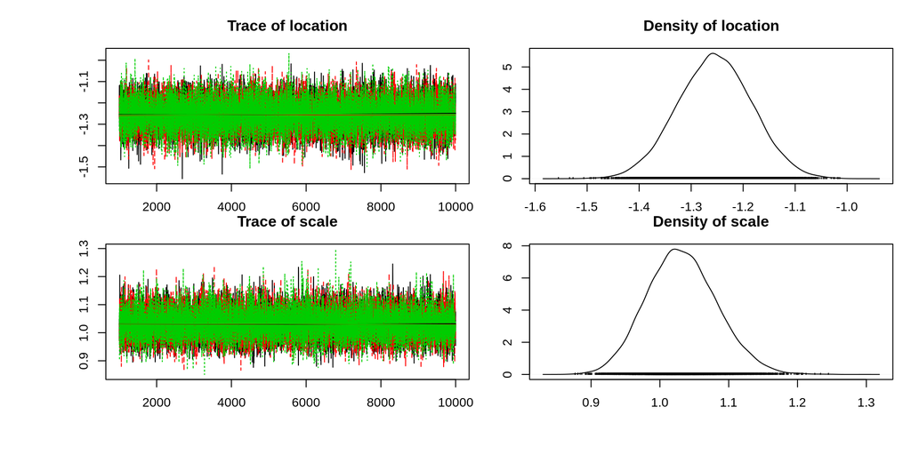

```r
# Density plot ------------------------------------------------------------

mcfit = as.mcmc(fit)

par(mar = c(1, 3, 3, 1),
    oma = c(4, 4, 0.2, 0.2),
    mfrow = c(2,2))
plot(mcfit)
```

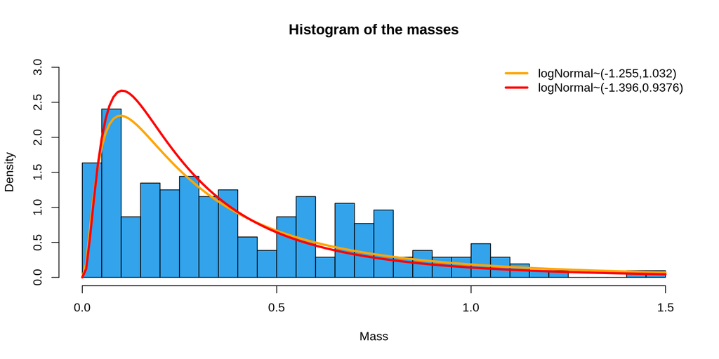

```r
hist(df$Mass, probability = T, breaks = 40, col = rgb(0,.55,.9,.8),
     main = "Histogram of the masses", xlab = "Mass", ylim = c(0, 3))

lines(seq(0,1.5,0.01), dlnorm(seq(0,1.5,0.01), -1.255,1.032), lwd = 3,
      col = "orange")
lines(seq(0,1.5,0.01), dlnorm(seq(0,1.5,0.01),  -1.396, 0.9376), lwd = 3,
      col = "red")
legend("topright", legend = c("logNormal~(-1.255,1.032)", "logNormal~(-1.396,0.9376)"),
       lwd = 3, col = c("orange", "red"), bty = 'n')
```

#### 4. Perform a quick sensitivity analysis by slightly changing the priors and reporting on the impact you see on your inferential conclusions.

```r
# Sensitivity Analysis ----------------------------------------------------

dd2 <- list(mu = 1,      # parameters of prior distribution
           tau_0 = 0.1,
           a = 0.1,
           b = 0.1,
           N = 208,
           y.log = c( 0.678, 0.402, 0.132, 0.27, 0.284, 0.12, 0.32, 0.086, 0.316,
                      0.579, 0.08, 0.479, 0.299, 0.028, 0.2, 0.085, 0.377, 0.768, 0.525,
                      0.337, 0.576, 0.068, 0.18, 0.091, 0.364, 0.671, 0.071, 0.095, 0.316,
                      0.221, 0.239, 0.518, 0.039, 0.395, 0.409, 0.375, 0.255, 0.584, 0.581,
                      0.231, 0.237, 0.76, 0.543, 0.649, 0.768, 0.415, 0.548, 0.236, 0.052,
                      0.056, 0.575, 0.174, 0.447, 0.368, 0.019, 0.265, 0.037, 0.062, 0.203,
                      0.074, 0.698, 0.55, 0.435, 0.699, 0.137, 0.054, 0.025, 0.693, 0.063,
                      0.32, 0.585, 0.644, 0.061, 0.349, 0.352, 0.745, 0.111, 0.545, 0.182,
                      0.599, 0.2, 0.373, 0.236, 0.067, 0.293, 0.671, 0.058, 0.419, 0.782,
                      0.324, 0.729, 0.51, 0.029, 0.042, 0.392, 0.481, 0.727, 0.185, 0.269,
                      0.732, 0.243, 0.695, 0.291, 0.703, 0.595, 0.191, 0.059, 0.573, 0.081,
                      0.571, 0.615, 0.084, 0.274, 0.196, 0.383, 0.195, 0.585, 0.477, 0.118,
                      0.25, 0.375, 0.066, 0.072, 0.082, 0.354, 0.158, 0.78, 0.126, 0.043,
                      0.241, 0.038, 0.034, 0.536, 0.198, 0.066, 0.284, 0.19, 0.026, 0.05,
                      0.079, 0.742, 0.231, 0.474, 0.05, 0.042, 0.136, 0.032, 0.157, 0.163,
                      0.063, 0.289, 0.854, 0.341, 0.274, 0.205, 0.654, 0.269, 0.106, 0.366,
                      0.34, 0.112, 0.35, 1.018, 0.791, 0.711, 0.796, 0.289, 0.345, 0.298,
                      0.672, 0.04, 0.502, 0.841, 0.243, 0.05, 0.699, 0.863, 0.816, 0.854,
                      0.594, 0.375, 0.316, 1.03, 0.951, 0.79, 0.772, 0.859, 0.951, 0.933,
                      1.129, 0.739, 0.925, 0.796, 1.029, 1.136, 1.092, 1.036, 0.818, 1.413,
                      1.022, 0.663, 1.078, 1.461, 1.19, 0.986, 1.099, 0.924, 1.23 )
)


fit2 <- jags(model = model, init = init,
            param = c("location", "scale"),
            data = dd2, n.iter = 10000,
            n.chain = 3, n.burn = 1000, n.thin = 1,
            DIC = FALSE)
fit2
```

```
## Inference for Bugs model at "/tmp/RtmpEyy5dP/model78cd173de00.txt", fit using jags,
##  3 chains, each with 10000 iterations (first 1000 discarded)
##  n.sims = 27000 iterations saved
##          mu.vect sd.vect   2.5%    25%    50%    75%  97.5%  Rhat n.eff
## location  -1.253   0.071 -1.395 -1.301 -1.253 -1.206 -1.113 1.001 27000
## scale      1.032   0.051  0.939  0.996  1.030  1.065  1.138 1.001 27000
##
## For each parameter, n.eff is a crude measure of effective sample size,
## and Rhat is the potential scale reduction factor (at convergence, Rhat=1).
```

The prior choosed for our (main) analysis are:

$Location \sim N(0, 1000)$

$Scale \sim Gamma(0.001, 0.001)$

in the sensitivity analysis we picked:

$Location \sim N(1, 10)$

$Scale \sim Gamma(0.1, 0.1)$

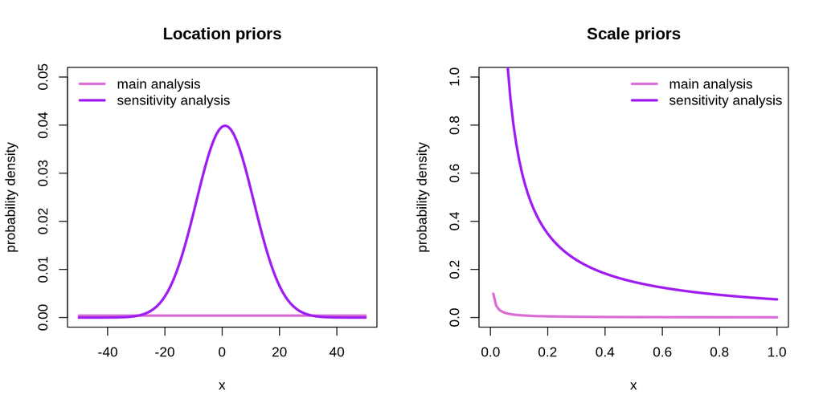

```r
# Prior plots ------------------------------------------------------------

par(mfrow=c(1,2))
curve(dnorm(x, dd[["mu"]], 1/dd[["tau_0"]]), ylim=c(0,0.05), col = "orchid", lwd = 3, main = "Location priors", ylab = 'probability density', xlim=c(-50, 50))
curve(dnorm(x, dd2[["mu"]], 1/dd2[["tau_0"]]), add = T, col = "purple", lwd = 3)
legend("topleft", col = c("orchid", "purple"), legend = c("main analysis", "sensitivity analysis"), lwd = 3, bty = 'n')

curve(dgamma(x, dd[["a"]], dd[["b"]]), ylim=c(0,1), col= "orchid", lwd = 3, main = "Scale priors",  ylab = 'probability density')
curve(dgamma(x, dd2[["a"]], dd2[["b"]]), add = T, col = "purple", lwd = 3)
legend("topright", col = c("orchid", "purple"), legend = c("main analysis", "sensitivity analysis"), lwd = 3, bty = 'n')
```

Even though we choosed more informative priors (the location and scale parameters are more “concentrated” around 0), we got almost the same inferential results. Moreover, we got a similar standard deviation for the parameter estimates. The model turns out to be not so sensible to our choices for the priors.